# Coursework Report

*N* removed NAs: 2

*N* removed typo: 1

*N* removed <18: 25

*N* total clean: 123

| Group | *N* | *M*<sub>age</sub> | *M*<sub>rating</sub> |
| --- | --- | --- | --- |
| Control | 63 | 20.9 | 5.79 |
| Experim | 60 | 21.2 | 6.91 |

**Main analysis results**

*t*(121) = -7.9, *p* < .001

[interactive chart not shown]

[figure not shown]

[interactive chart not shown]

# Coursework Report

Analysing Data, Spring 2020

# Methods

## Participants

Figure 1 shows the distribution of conditions as well as an age breakdown by condition.

| Condition | N | % | *M*<sub>age</sub> | *SD*<sub>age</sub> |
| --- | --- | --- | --- | --- |
| control | 63 | 51.2 | 20.9 | 2.04 |
| experimental | 60 | 48.8 | 21.2 | 2.24 |

**Figure 1 Descriptive statistics by categories of Condition**

## Design

This study’s aim was to recreate Elliot et al (2010)’s Experiment 1 in an attempt to further investigate how human attraction is influenced via colour. By comparing results, this current study can investigate whether the red effect found in Elliot’s original study is supported or opposed.

In this study, the dependant variable was a ‘perceived attractiveness rating’ which was measured using a 9-point perceived attractiveness answering scale. This rating was calculated by incorporating the same three questions used by Elliot et al (2010). “How attractive do you think this person is?” “How pleasant is this person to look at?” and “If I were to meet the person in this picture face to face, I would think he is attractive.” These questions were rated from, 1 (not at all attractive) to 9 (extremely attractive), Each question’s rating score was combined to form an overall composite score. As such, a higher score would indicate an increased perceived attraction.

The independant variable was the frame colour of a photograph of a young Caucasian male. This categorical variable comprised of an experimental group, and control group. In the experimental group, participants viewed the photograph with a red frame and then responded to the three questions. In the control condition, participants viewed the same picture, but with a white frame and then responded to the three questions. This study used the same photo, dimensions, colours and viewing time as the original study Elliot et al. (2010).

For this experiment, we hypothesize that participants’ mean ratings of percieved attractiveness will be influenced depending on the frame colour of a photograph of a Caucasian male. To test this hypothesis, an independant-samples t-test analysis was conducted.

# Results

The mean of each participant’s scores on the three question ratings were collected and then grouped by condition to form composite scores for each condition. Then, these were used to produce a mean plot, as shown in Figure 2.

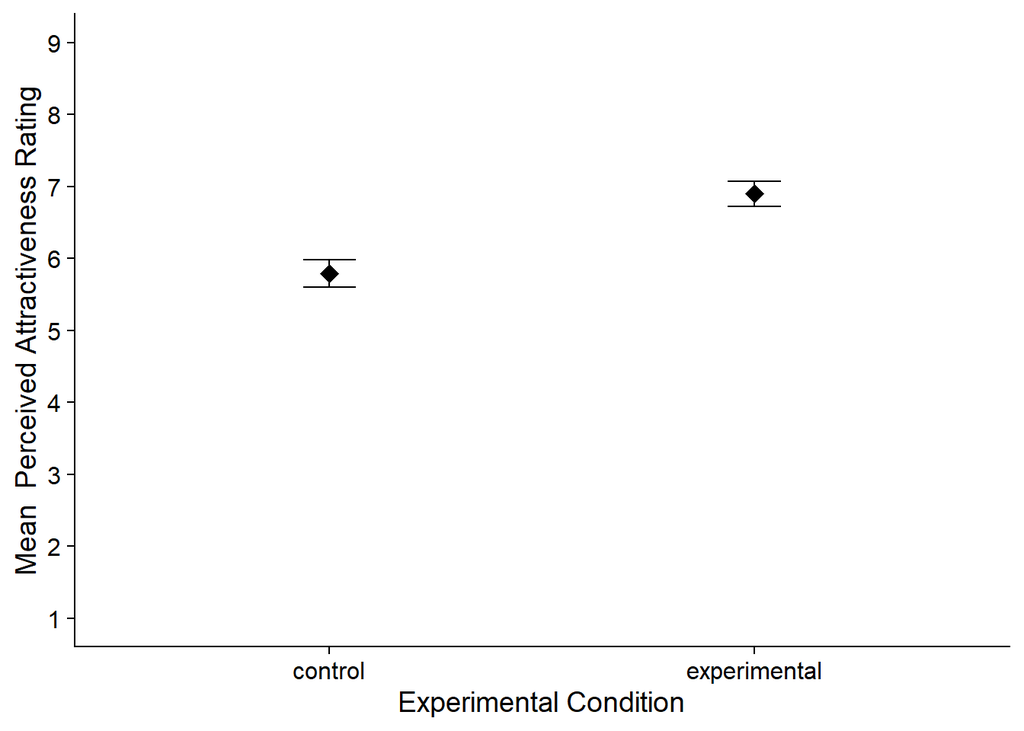

**Figure 2. A mean plot to show the effect of expreimental condition on mean perceiveed attractiveness rating (95% CI)**.

*M*<sub>experimental</sub> 6.91 - *M*<sub>control</sub> 5.79 = (*M*<sub>diff</sub> = 1.12)

The means of perceived attractiveness in the two conditions are different from one another. The experimental group participants rated the male 1.12 ratings higher in male attractiveness compared to the control group. This suggests that in this experiment, viewing the red coloured frame, increased attractiveness ratings of the male in the photograph. There are no overlapping error bars at 95% CI which suggests these results are statistically significant and 95% of these intervals around sample estimates will contain the value of the population mean. The small width of the interval suggests there is certainty not to expect the mean of another same sized different sample to significantly vary from this sample. However, an independant-samples t-test will be needed to be sure of this interpretation.

```
##
##  Two Sample t-test
##
## data:  attractiveness_comp by group
## t = -8, df = 121, p-value = 0.000000000001
## alternative hypothesis: true difference in means is not equal to 0
## 95 percent confidence interval:
##  -1.397 -0.837
## sample estimates:
##      mean in group control mean in group experimental
##                       5.79                       6.91
```

This test showed a significant difference in the mean perceived attractiveness rating of the two conditions ((*M*<sub>diff</sub> = -1.12, 95% CI [-1.4, -0.84], *t* (121) = -7.9, *p* = < .001.)

This t-test retrieved a t-value of -7.9 which highlights that the difference between the sample means of -1.12 was -7.9 times greater than the standard error of the difference in means. The probability of getting a value of this magnitude if the true difference in means is 0, is very unlikely *p* = < .001. As such, it is unlikely that these sample means came from the same population. As a result, the null hypothesis may not be true.

# Discussion

This current study aimed to directly replicate Elliot et al.’s original experiment 1 (Elliot et al., 2010). We hypothesized that perceived attractiveness ratings would be influenced by the frame colour of a photograph of a Caucasian male. Our replication found a statistically significant effect on the colour red influencing perceived attraction ratings. Therefore, this experiment supports Elliot’s claim that a ‘red effect’ influences attraction.

Participants in the experimental condition gave higher ratings of perceived attractiveness -1.12 with the difference between the mean ratings being statistically significant at 95% CI ((*M*<sub>diff</sub> = -1.12, 95% CI [-1.4, -0.84], *t* (121) = -7.9, *p* = < .001.) It is unlikely that these sample means came from the same population. As a result, the null hypothesis may not be true.

However, other replications of the original experiment have also used sufficient participants amounts yet failed to find statistically significant effects of red on attraction. (144 participants (Elliot.2013) and 72 participants (Hesslinger, 2015)) This inconsistent pattern of results within this area of scientific research demonstrates that the red attraction effect may not be as robust as the results of this current study and the original study would otherwise suggest. This conflict may be a result of weaknesses in experimental design or other factors also influencing the perception of attractiveness.

For instance, in this experiment only one ‘moderately attractive’ male photograph was used to investigate the red effect. This design is a limitation as photographs may constrain the red effect to a limited range of human features/ behaviours compared to real life. For example, it is suggested females may be capable of observing natural changes in redness of male’s skin (Elliot, 2014). This capability may influence the magnitude of the red effect in real life, yet the use of a photograph in this current experiment does not consider this potential aspect of the red effect. As such, the results in this study design cannot explain whether our reported increased attractiveness rating/ red effect obtained will have the same effect when it is observed within reality in everyday contexts (Gerger, 2011).A future study could consider whether this current study’s observed magnitude of the red effect can be influenced by the addition of different forms of red on a male target (e.g. changing redness in skin, red clothes, red framed photograph etc.). Results could be compared with this current study to learn if different forms of red cause the red effect to increase more in some forms than others.

The idea that considering more implementations of red are required for a more accurate red effect can be further supported. In a meta-analysis that selected various implementations of redness, (frame, facial redness, red clothes etc) only a very small red effect was found, d = 0.13, 95% CI [0.01, 0.25], p = .03, n = 2,739. (Lehmann, 2018) This is a much smaller red effect than what this current study found. This difference could indicate that when the presence of red is analysed when it is implemented in a variety of ways, the overall extent red can influence attractiveness diminishes. Therefore, this study of a red border may provide an unrealistically increased estimation of the overall red effect that is present across other red features (red clothing or skin redness). .

A study found that the red effect was only present for female faces that were pre-rated as attractive. (Young, 2015) Given that this design used a ‘moderately attractive’ Caucasian male, this could suggest that our presence of the red effect, calculated mean difference between conditions, may only have been established due to the pre rated attractiveness of the male and not solely the red frame colour of the photograph. Therefore, in order for this experiment to establish the true effect red has on attractiveness, a future study would need to use a large range of photographs to control the effect pre-attractiveness may have on influencing red attraction.

In summary, our replication study supports ‘red effect’ claim. (Elliot et al., 2010) There was a statistically significant effect red had on perceived attraction ratings. Additionally, this study’s incorporation of a larger sample provides a larger power, and scientific credibility to support the ‘red effect’ found in Elliot’s original study. However, when contrasting data from other replications the complexity of factors that impact attraction is revealed. This study only considers colour framed photographs, yet research has found this alone may not create representative feelings of attraction. (Lehmann, 2018) As such, since our representation of the red effect only considers a red framed photograph, it may be that our observed red effect is lower when considering the presence of red with varying forms/ real life context. (Lehmann, 2018). Follow up studies could consider adding more implementations of red presence so that new results could be compared with this current study to learn if different forms of red cause the red effect to increase more in some forms than others.

# References

Elliot, A. J., Niesta Kayser, D., Greitemeyer, T., Lichtenfeld, S., Gramzow, R. H., Maier, M. A., & Liu, H. (2010). Red, rank, and romance in women viewing men. *Journal of Experimental Psychology: General, 139*(3), 399.

Elliot. (2014). Color Psychology: Effects of Perceiving Color on Psychological Functioning in Humans. Annual Review of Psychology Vol. 65.

Elliot. (2013). The red-attractiveness effect, applying the Ioannidis and Trikalinos (2007b) test, and the broader scientific context: A reply to Francis (2013). . Journal of Experimental Psychology: General, 142(1), , 297–300.

Francis, G. (2013). Publication bias in “Red, rank, and romance in women viewing men,” by Elliot et al. (2010). .Journal of Experimental Psychology: General Vol. 142, Iss. 1,, 292-296.

Gerger, G. L. (2011). When the others matter: Context-dependent effects on changes in appreciation of innovativeness. . Swiss Journal of Psychology, 70(2), , 75–83.

Hesslinger, V. M. (2015). Men in red: A reexamination of the red-attractiveness effect. Psychonomic Bulletin & Review volume 22, pages1142–1148(2015), pages1142–1148.

Lehmann, G. K. (2018). Meta-Analysis of the Effect of Red on Perceived Attractiveness. Evolutionary Psychology, vol. 16, 4,

Young, S. G. (2015). The effect of red on male perceptions of female attractiveness: Moderation by baseline attractiveness of female faces. European Journal of Social Psychology, 45, , 146–151.